# Cardiometabolic Risk in NHANES 2017–2018

A polyglot R + Python analysis with complex survey design, machine learning, and SHAP interpretability

Author

Paulina Del Mundo Del Fierro, MD, MPH

Published

April 28, 2026

## 1 Why this analysis

Cardiometabolic disease remains the leading driver of mortality in US adults. Yet the clinical tools that estimate risk — Framingham, ASCVD, PCE — were trained on cohorts that poorly represent the population-level distribution of social and biological risk factors captured by NHANES.

This notebook does three things a physician-scientist portfolio should demonstrate end-to-end:

1. **Load and harmonize** the NHANES 2017–2018 cycle (demographics, examination, labs, questionnaire) using the CDC’s public XPT files.
2. **Describe** the population correctly — applying the NHANES complex survey design so prevalence estimates generalize to the US civilian non-institutionalized population.
3. **Model** the probability of metabolic syndrome using both a design-aware logistic regression (in **R**) and a gradient-boosted classifier with SHAP explanations (in **Python**), then compare what each approach reveals.

The two language blocks render side-by-side thanks to Quarto’s polyglot mode via `reticulate` — a small but real demonstration that **methodology choices should follow the scientific question, not the toolchain.**

**Note**

Source and helpers live in `R/nhanes_helpers.R` and `python/nhanes_helpers.py`. The `.qmd` source for this page is on [GitHub](https://github.com/paulinedmdf/paulinadelmundomd/blob/main/projects/01-cardiometabolic-risk/analysis.qmd).

## 2 Setup

```r
source(here::here("R", "nhanes_helpers.R"))
library(gtsummary)
library(ggplot2)
library(purrr)
library(reticulate)

# Method packages — installed on first render if absent.
for (pkg in c("mice", "mitools", "e1071", "fitdistrplus",
              "performance", "lme4", "kableExtra")) {
  if (!requireNamespace(pkg, quietly = TRUE)) {
    install.packages(pkg, repos = "https://cloud.r-project.org")
  }
}
# Lightweight wrapper for hero tables — bootstrap styling, no monospaced
# greyscale dump. Plain knitr::kable() still works elsewhere for inline /
# diagnostic tables where the styled version is overkill.
pretty_kable <- function(x, caption = NULL, ...) {
  knitr::kable(x, caption = caption, ...) |>
    kableExtra::kable_styling(
      bootstrap_options = c("striped", "hover", "condensed", "responsive"),
      full_width        = FALSE,
      position          = "left",
      font_size         = 13
    )
}

reticulate::py_require(c(
  "pandas", "numpy", "scipy", "scikit-learn",
  "xgboost", "shap", "matplotlib"
))
theme_set(theme_minimal(base_size = 12))
```

```python
import sys, pathlib
sys.path.append(str(pathlib.Path.cwd().parents[1] / "python"))

import numpy as np
import pandas as pd
import matplotlib.pyplot as plt
from sklearn.model_selection import train_test_split
from sklearn.metrics import roc_auc_score, roc_curve, brier_score_loss
from sklearn.calibration import calibration_curve
import xgboost as xgb
import shap

plt.rcParams.update({"figure.dpi": 110})
```

## 3 Pulling and pooling the NHANES cycles

A single cycle is too small for stable subgroup estimates. We pool **NHANES 2015–2016 (cycle I)** and **2017–2018 (cycle J)** per the CDC analytic guidelines: each cycle’s MEC weight is divided by the number of cycles, strata and PSU pass through unchanged, and SEQNs don’t collide. The combined-cycle weight is `WTMEC4YR = WTMEC2YR / 2`.

We also pull three additional tables (`TCHOL`, `SMQ`, `BPQ`) needed for the Pooled Cohort Equations comparator downstream — total cholesterol, current-smoker status, and antihypertensive treatment.

```r
build_spec <- function(suffix) {
  list(
    DEMO  = paste0("DEMO_",   suffix),
    BMX   = paste0("BMX_",    suffix),
    BPX   = paste0("BPX_",    suffix),
    GLU   = paste0("GLU_",    suffix),
    HDL   = paste0("HDL_",    suffix),
    TRIG  = paste0("TRIGLY_", suffix),
    DIQ   = paste0("DIQ_",    suffix),
    TCHOL = paste0("TCHOL_",  suffix),
    SMQ   = paste0("SMQ_",    suffix),
    BPQ   = paste0("BPQ_",    suffix)
  )
}

cycle_specs <- list(
  "2015-2016" = build_spec("I"),
  "2017-2018" = build_spec("J")
)

nhanes_raw <- pool_nhanes_cycles(cycle_specs)
nhanes_raw <- recode_demographics(nhanes_raw)

cat(sprintf("Pooled rows: %s\n", format(nrow(nhanes_raw), big.mark = ",")))
```

```
Pooled rows: 19,225
```

```r
print(table(cycle = nhanes_raw$cycle))
```

```
cycle
2015-2016 2017-2018
     9971      9254
```

## 4 Exploratory data analysis — what the cohort actually looks like

Before any modeling decision, four questions need answers: **what’s missing, how skewed are the continuous variables, how do the demographic cells distribute, and does the cohort that survives our exclusion criteria still resemble the source population?** Skipping these steps is how a survey-weighted estimator ends up reporting a tidy CI on a heavily-truncated subgroup.

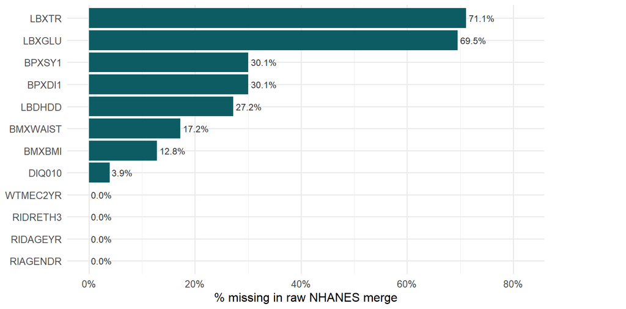

```r
eda_cols <- c("WTMEC2YR", "RIAGENDR", "RIDAGEYR", "RIDRETH3",
              "BMXBMI", "BMXWAIST",
              "BPXSY1", "BPXDI1",
              "LBXTR", "LBDHDD", "LBXGLU", "DIQ010")

miss_long <- nhanes_raw |>
  dplyr::select(dplyr::any_of(eda_cols)) |>
  dplyr::summarise(dplyr::across(dplyr::everything(),
                                 \(x) mean(is.na(x)) * 100)) |>
  tidyr::pivot_longer(dplyr::everything(),
                      names_to = "variable", values_to = "pct_missing")

ggplot(miss_long,
       aes(x = stats::reorder(variable, pct_missing), y = pct_missing)) +
  geom_col(fill = "#0d5c63") +
  geom_text(aes(label = sprintf("%.1f%%", pct_missing)),
            hjust = -0.1, size = 3.2, color = "#333") +
  coord_flip(clip = "off") +
  scale_y_continuous(limits = c(0, max(miss_long$pct_missing) * 1.15),
                     labels = \(x) paste0(x, "%")) +
  labs(x = NULL, y = "% missing in raw NHANES merge") +
  theme(plot.margin = margin(5, 80, 5, 5))
```

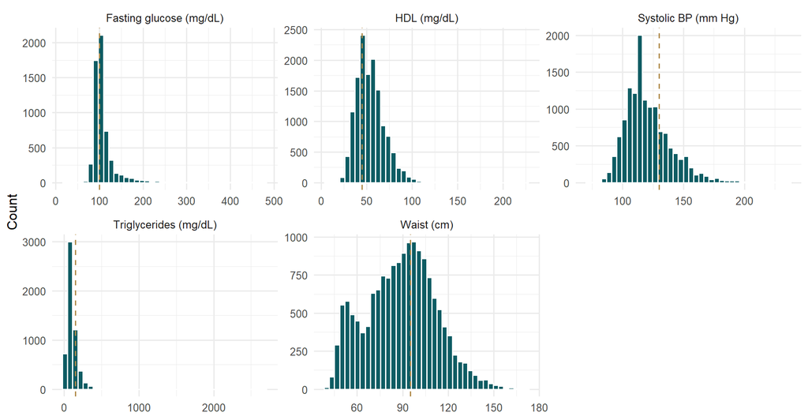

Univariate distributions of the five continuous components used downstream. Triglycerides and fasting glucose are right-skewed with long upper tails — this is exactly the regime where peer-comparison estimators like robust z-scores beat naive means. Vertical lines mark ATP III diagnostic thresholds.

```r
cont_long <- nhanes_raw |>
  dplyr::transmute(
    `Waist (cm)`              = BMXWAIST,
    `Triglycerides (mg/dL)`   = LBXTR,
    `HDL (mg/dL)`             = LBDHDD,
    `Systolic BP (mm Hg)`     = BPXSY1,
    `Fasting glucose (mg/dL)` = LBXGLU
  ) |>
  tidyr::pivot_longer(dplyr::everything(),
                      names_to = "variable", values_to = "value") |>
  dplyr::filter(!is.na(value))

thresholds <- tibble::tibble(
  variable = c("Waist (cm)", "Triglycerides (mg/dL)",
               "HDL (mg/dL)", "Systolic BP (mm Hg)",
               "Fasting glucose (mg/dL)"),
  cut      = c(95, 150, 45, 130, 100)
)

ggplot(cont_long, aes(value)) +
  geom_histogram(fill = "#0d5c63", color = "white", bins = 40) +
  geom_vline(data = thresholds, aes(xintercept = cut),
             color = "#b08a49", linetype = "dashed", linewidth = 0.6) +
  facet_wrap(~ variable, scales = "free", ncol = 3) +
  labs(x = NULL, y = "Count")
```

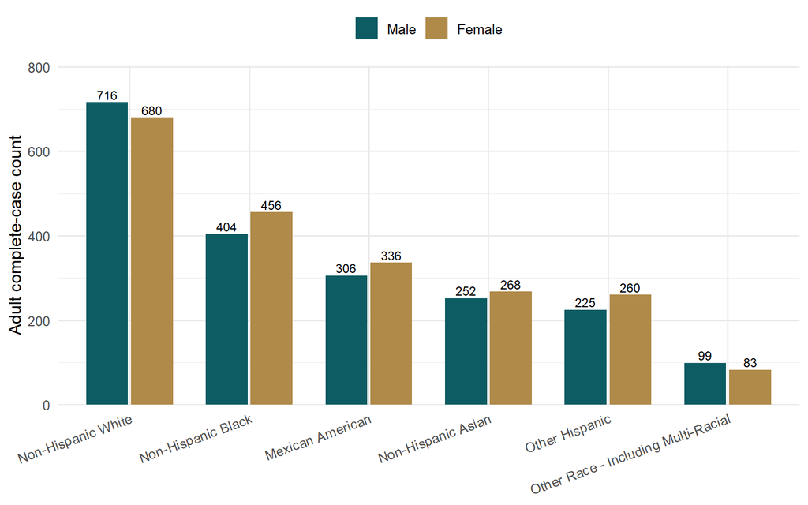

Sex × race/ethnicity cell counts after the adult (≥ 20) and complete-case filter. Cells under ~30 will produce wide CIs in subgroup estimates — a sanity check before reporting any stratified prevalence.

```r
dat_eda <- nhanes_raw |>
  dplyr::filter(age_years >= 20, !is.na(WTMEC2YR)) |>
  dplyr::filter(if_all(c(BMXWAIST, LBXTR, LBDHDD, BPXSY1, BPXDI1, LBXGLU),
                        \(x) !is.na(x)))

cells <- dat_eda |>
  dplyr::count(sex, race_eth) |>
  dplyr::mutate(race_eth = forcats::fct_reorder(race_eth, n, .desc = TRUE))

ggplot(cells, aes(race_eth, n, fill = sex)) +
  geom_col(position = position_dodge(0.75), width = 0.7) +
  geom_text(aes(label = n),
            position = position_dodge(0.75), vjust = -0.3, size = 3.1) +
  scale_fill_manual(values = c("Male" = "#0d5c63", "Female" = "#b08a49")) +
  scale_y_continuous(expand = expansion(mult = c(0, 0.12))) +
  labs(x = NULL, y = "Adult complete-case count", fill = NULL) +
  theme(legend.position = "top",
        axis.text.x = element_text(angle = 20, hjust = 1))
```

```r
target <- dat_eda |>
  dplyr::transmute(
    waist_hit = (sex == "Male"   & BMXWAIST >= 102) |
                (sex == "Female" & BMXWAIST >= 88),
    trig_hit  = LBXTR >= 150,
    hdl_hit   = (sex == "Male"   & LBDHDD < 40) |
                (sex == "Female" & LBDHDD < 50),
    bp_hit    = BPXSY1 >= 130 | BPXDI1 >= 85,
    glu_hit   = LBXGLU >= 100,
    metsyn    = rowSums(cbind(waist_hit, trig_hit, hdl_hit, bp_hit, glu_hit), na.rm = TRUE) >= 3
  )

cat(sprintf(
  "Adult complete-case n = %s\nUnweighted MetS prevalence  = %.1f%%\n",
  format(nrow(target), big.mark = ","),
  100 * mean(target$metsyn, na.rm = TRUE)
))
```

```
Adult complete-case n = 4,085
Unweighted MetS prevalence  = 37.7%
```

The unweighted prevalence above is what a naive analyst would report. The weighted estimate in the next section will land in a different place — that gap is the methodological reason we apply the survey design.

## 5 Defining metabolic syndrome (ATP III, harmonized)

An adult meets criteria if **≥ 3 of 5** are true:

| Component | Threshold |
| --- | --- |
| Waist circumference | ≥ 102 cm (M) or ≥ 88 cm (F) |
| Triglycerides | ≥ 150 mg/dL |
| HDL cholesterol | < 40 mg/dL (M) or < 50 mg/dL (F) |
| Blood pressure | SBP ≥ 130 or DBP ≥ 85, or on BP medication |
| Fasting glucose | ≥ 100 mg/dL, or on diabetes medication |

```r
# Pre-complete-case cohort — keep one copy with NAs intact for MICE downstream,
# and one filtered copy for the design-aware analysis the existing chunks
# already use. The outcome derivation is identical; only the row filter
# differs.
dat_full <- nhanes_raw |>
  filter(age_years >= 20, !is.na(WTMEC4YR), WTMEC4YR > 0) |>
  transmute(
    SEQN, cycle, WTMEC4YR, SDMVPSU, SDMVSTRA,
    sex, age_years, race_eth,
    bmi          = BMXBMI,
    waist        = BMXWAIST,
    trig         = LBXTR,
    hdl          = LBDHDD,
    tc           = LBXTC,
    sbp          = rowMeans(cbind(BPXSY1, BPXSY2, BPXSY3), na.rm = TRUE),
    dbp          = rowMeans(cbind(BPXDI1, BPXDI2, BPXDI3), na.rm = TRUE),
    fpg          = LBXGLU,
    dm_dx        = !is.na(DIQ010) & DIQ010 == "Yes",
    bp_treated   = !is.na(BPQ050A) & BPQ050A == "Yes",
    smoker       = !is.na(SMQ040) & SMQ040 %in% c("Every day", "Some days"),
    waist_hit    = (sex == "Male"   & waist >= 102) |
                   (sex == "Female" & waist >= 88),
    trig_hit     = trig >= 150,
    hdl_hit      = (sex == "Male"   & hdl < 40) |
                   (sex == "Female" & hdl < 50),
    bp_hit       = sbp >= 130 | dbp >= 85,
    glu_hit      = fpg >= 100 | dm_dx,
    mets_n       = rowSums(cbind(waist_hit, trig_hit, hdl_hit, bp_hit, glu_hit),
                           na.rm = TRUE),
    metsyn       = mets_n >= 3
  )

# Coerce sbp/dbp NaN (when all three readings missing) back to NA so MICE
# treats them consistently.
dat_full <- dat_full |>
  mutate(across(c(sbp, dbp), \(x) ifelse(is.nan(x), NA, x)))

dat <- dat_full |>
  filter(if_all(c(waist, trig, hdl, sbp, dbp, fpg), \(x) !is.na(x)))

cat(sprintf(
  "Pre-CC pooled cohort  : %s\nComplete-case cohort  : %s (drop %.1f%%)\n",
  format(nrow(dat_full), big.mark = ","),
  format(nrow(dat),      big.mark = ","),
  100 * (1 - nrow(dat) / nrow(dat_full))
))
```

```
Pre-CC pooled cohort  : 10,739
Complete-case cohort  : 4,314 (drop 59.8%)
```

## 6 Diagnostics on the analytic cohort

Three publication-grade checks before any modeling: a **formal distributional fit** for each continuous candidate (skew/kurtosis quantified, candidate distributions ranked by AIC), a **selection-bias check** comparing the dropped rows to the kept ones, and an **ICC variance partition** that quantifies how much of the outcome variance lives at each clustering level of the NHANES sample design.

```r
cont_vars <- list(
  bmi   = dat_full$bmi,   waist = dat_full$waist,
  trig  = dat_full$trig,  hdl   = dat_full$hdl,
  sbp   = dat_full$sbp,   dbp   = dat_full$dbp,
  fpg   = dat_full$fpg,   tc    = dat_full$tc
)

skew_kurt <- vapply(cont_vars, function(x) {
  x <- x[!is.na(x)]
  c(skew = e1071::skewness(x), kurtosis = e1071::kurtosis(x))
}, numeric(2))

knitr::kable(
  data.frame(
    Variable = colnames(skew_kurt),
    n        = vapply(cont_vars, \(x) sum(!is.na(x)), integer(1)),
    Skew     = round(skew_kurt["skew", ], 2),
    `Excess kurtosis` = round(skew_kurt["kurtosis", ], 2),
    Shape    = ifelse(abs(skew_kurt["skew", ]) > 1, "Right-skewed",
                ifelse(abs(skew_kurt["skew", ]) > 0.5, "Mildly skewed", "Roughly symmetric")),
    check.names = FALSE
  ),
  caption = "Skewness and excess kurtosis on the eight continuous candidate variables. |skew| > 1 indicates a heavy tail that materially affects the choice of regression family or transformation. The right-skewed variables get a formal distribution fit in the next table."
)
```

Skewness and excess kurtosis on the eight continuous candidate variables. |skew| > 1 indicates a heavy tail that materially affects the choice of regression family or transformation. The right-skewed variables get a formal distribution fit in the next table.

|  | Variable | n | Skew | Excess kurtosis | Shape |
| --- | --- | --- | --- | --- | --- |
| bmi | bmi | 10581 | 1.20 | 2.72 | Right-skewed |
| waist | waist | 10053 | 0.55 | 0.37 | Mildly skewed |
| trig | trig | 4647 | 9.08 | 165.45 | Right-skewed |
| hdl | hdl | 10094 | 1.22 | 3.80 | Right-skewed |
| sbp | sbp | 10311 | 1.03 | 1.79 | Right-skewed |
| dbp | dbp | 10311 | -0.49 | 3.49 | Roughly symmetric |
| fpg | fpg | 4887 | 3.87 | 19.46 | Right-skewed |
| tc | tc | 10094 | 0.73 | 2.09 | Mildly skewed |

```r
skewed <- names(cont_vars)[abs(skew_kurt["skew", ]) > 1]
fit_results <- list()
for (v in skewed) {
  x <- cont_vars[[v]]
  x <- x[!is.na(x) & x > 0]
  fits <- list(
    normal = try(fitdistrplus::fitdist(x, "norm"),  silent = TRUE),
    lnorm  = try(fitdistrplus::fitdist(x, "lnorm"), silent = TRUE),
    gamma  = try(fitdistrplus::fitdist(x, "gamma"), silent = TRUE)
  )
  aics <- vapply(fits, function(f) {
    if (inherits(f, "try-error") || is.null(f)) NA_real_ else f$aic
  }, numeric(1))
  fit_results[[v]] <- aics
}

if (length(fit_results) > 0) {
  fit_mat <- do.call(rbind, fit_results)
  best    <- colnames(fit_mat)[apply(fit_mat, 1, function(r) which.min(r))]
  knitr::kable(
    data.frame(
      Variable = rownames(fit_mat),
      `AIC normal` = round(fit_mat[, "normal"], 0),
      `AIC log-normal` = round(fit_mat[, "lnorm"], 0),
      `AIC gamma` = round(fit_mat[, "gamma"], 0),
      `Best fit`  = best,
      check.names = FALSE
    ),
    caption = "AIC comparison of three candidate distributions on the right-skewed variables (positive values only). Lowest AIC = best fit. The 'best fit' column is the recommended starting family for any regression that takes one of these as outcome — for triglycerides and fasting glucose the answer is almost always log-normal or gamma rather than normal."
  )
}
```

AIC comparison of three candidate distributions on the right-skewed variables (positive values only). Lowest AIC = best fit. The ‘best fit’ column is the recommended starting family for any regression that takes one of these as outcome — for triglycerides and fasting glucose the answer is almost always log-normal or gamma rather than normal.

|  | Variable | AIC normal | AIC log-normal | AIC gamma | Best fit |
| --- | --- | --- | --- | --- | --- |
| bmi | bmi | 71912 | 70103 | 70500 | lnorm |
| trig | trig | 56021 | 50596 | 51327 | lnorm |
| hdl | hdl | 85525 | 83841 | 84056 | lnorm |
| sbp | sbp | 90275 | 89124 | 89427 | lnorm |
| fpg | fpg | 49837 | 46203 | 47234 | lnorm |

```r
# Tag inclusion status, then formally test whether the included and
# excluded subsamples differ on the demographics we're going to condition
# on downstream. Significant differences quantify the selection-bias
# threat that motivates MICE in a later section.
dat_full2 <- dat_full |>
  dplyr::mutate(included = SEQN %in% dat$SEQN)

n_inc <- sum(dat_full2$included)
n_exc <- sum(!dat_full2$included)

results <- list(
  age_years = stats::t.test(age_years ~ included, data = dat_full2),
  bmi       = stats::t.test(bmi       ~ included, data = dat_full2),
  sex       = stats::chisq.test(table(dat_full2$sex,      dat_full2$included)),
  race_eth  = stats::chisq.test(table(dat_full2$race_eth, dat_full2$included)),
  cycle     = stats::chisq.test(table(dat_full2$cycle,    dat_full2$included))
)

bias_df <- data.frame(
  Variable    = names(results),
  Test        = c("Welch t", "Welch t", "Pearson chi-squared",
                  "Pearson chi-squared", "Pearson chi-squared"),
  Statistic   = vapply(results, \(r) round(as.numeric(r$statistic), 2), numeric(1)),
  df          = vapply(results, \(r) {
    p <- if (!is.null(r$parameter)) as.numeric(r$parameter[1]) else NA_real_
    if (is.na(p)) "" else as.character(round(p, 1))
  }, character(1)),
  `p-value`   = vapply(results, \(r) format.pval(r$p.value, eps = 1e-300, digits = 2),
                       character(1)),
  check.names = FALSE
)

cat(sprintf("Included (complete-case) : %s\nExcluded                : %s\n\n",
            format(n_inc, big.mark = ","),
            format(n_exc, big.mark = ",")))
```

```
Included (complete-case) : 4,314
Excluded                : 6,425
```

```r
knitr::kable(
  bias_df,
  caption = "Selection-bias diagnostics: do the rows we drop in the complete-case filter differ from the rows we keep, on the demographics that condition the downstream regression? Significant differences (typically on age, since fasting subsamples skew older) quantify the threat that motivates the MICE section below."
)
```

|  | Variable | Test | Statistic | df | p-value |
| --- | --- | --- | --- | --- | --- |
| age_years | age_years | Welch t | -0.72 | 9448 | 0.47 |
| bmi | bmi | Welch t | 1.33 | 9547.8 | 0.18 |
| sex | sex | Pearson chi-squared | 0.87 | 1 | 0.35 |
| race_eth | race_eth | Pearson chi-squared | 4.67 | 5 | 0.46 |
| cycle | cycle | Pearson chi-squared | 8.83 | 1 | 0.003 |

```r
# Partition the variance of MetS at NHANES's complex-survey clustering
# levels — strata, then PSU within stratum. Subject-level variance
# falls out as the residual.
icc_model <- lme4::glmer(
  as.integer(metsyn) ~ 1 + (1 | SDMVSTRA) + (1 | SDMVPSU),
  data    = dat,
  family  = binomial(),
  control = lme4::glmerControl(optimizer = "bobyqa")
)

vc <- as.data.frame(lme4::VarCorr(icc_model))[, c("grp", "vcov")]
# For binomial GLMM with logit link, the residual variance is fixed at
# pi^2 / 3 on the latent scale (Snijders & Bosker convention).
vc <- rbind(vc, data.frame(grp = "Residual (latent)", vcov = pi^2 / 3))
total <- sum(vc$vcov)
vc$ICC_pct <- sprintf("%.2f%%", 100 * vc$vcov / total)
vc$Variance <- round(vc$vcov, 4)

knitr::kable(
  vc[, c("grp", "Variance", "ICC_pct")],
  col.names = c("Clustering level", "Variance", "% of total"),
  caption = "Variance partition for binary MetS via random-intercept logit. Stratum + PSU together carry the design-induced clustering; the residual is the per-subject variance on the latent (logit) scale (pi^2/3 by convention). When the stratum + PSU share is non-trivial, design-aware estimators are doing real inferential work — not a stylistic choice."
)
```

Variance partition for binary MetS via random-intercept logit. Stratum + PSU together carry the design-induced clustering; the residual is the per-subject variance on the latent (logit) scale (pi^2/3 by convention). When the stratum + PSU share is non-trivial, design-aware estimators are doing real inferential work — not a stylistic choice.

| Clustering level | Variance | % of total |
| --- | --- | --- |
| SDMVSTRA | 0.0480 | 1.44% |
| SDMVPSU | 0.0000 | 0.00% |
| Residual (latent) | 3.2899 | 98.56% |

## 7 Weighted prevalence by demographics

> **In one sentence.** Apply the NHANES design weights so prevalence estimates generalize to the US civilian non-institutionalized population — and report the weighted estimate as the headline rather than the unweighted one.

**NoteWhy a survey-weighted estimator (and not a plain proportion)?**

NHANES is **not a simple random sample.** It deliberately *oversamples* certain subgroups (older adults, Black, Hispanic, low-income) so the lab work has enough cases per cell to estimate subgroup prevalence precisely. If you compute a plain proportion on the raw rows, you over-count those oversampled groups in the headline number.

The fix is the **MEC sample weight (`WTMEC2YR`)** — a number per row that says “this person represents *N* people in the US population.” A weighted mean reweights every row by `WTMEC2YR` so the result is what you’d see if NHANES had been a true random sample of the US adult population. The `survey::svymean()` function also accounts for the sampling **strata** and **PSUs** (geographic clusters), so the standard error reflects the design — not the smaller SE you’d get pretending the sample was simple-random.

**Use a weighted estimator whenever a sample was drawn with unequal probabilities — NHANES, BRFSS, MEPS, NHIS, NHATS, all the federal surveys.** The unweighted version isn’t “simpler”; it’s biased.

Critically, NHANES oversamples certain subpopulations. A naive proportion is biased; we have to apply the MEC sampling weights with `survey`/`srvyr`.

```r
des <- nhanes_design(dat, weight = "WTMEC4YR")

prev_tbl <- des |>
  group_by(sex, race_eth) |>
  summarize(
    metsyn_pct = survey_mean(metsyn, proportion = TRUE, vartype = "ci") * 100
  )

pretty_kable(
  prev_tbl,
  digits = 1,
  col.names = c("Sex", "Race/Ethnicity", "Prevalence (%)", "Lower 95% CI", "Upper 95% CI"),
  caption = "Weighted metabolic syndrome prevalence, US adults ≥ 20 years (NHANES 2015–2018, pooled)."
)
```

Weighted metabolic syndrome prevalence, US adults ≥ 20 years (NHANES 2015–2018, pooled).

| Sex | Race/Ethnicity | Prevalence (%) | Lower 95% CI | Upper 95% CI |
| --- | --- | --- | --- | --- |
| Male | Mexican American | 37.7 | 32.9 | 42.8 |
| Male | Other Hispanic | 36.1 | 28.0 | 45.1 |
| Male | Non-Hispanic White | 37.3 | 32.7 | 42.2 |
| Male | Non-Hispanic Black | 22.2 | 18.2 | 26.9 |
| Male | Non-Hispanic Asian | 25.3 | 20.3 | 31.1 |
| Male | Other Race - Including Multi-Racial | 37.6 | 24.1 | 53.4 |
| Female | Mexican American | 44.7 | 38.5 | 51.2 |
| Female | Other Hispanic | 34.2 | 28.4 | 40.5 |
| Female | Non-Hispanic White | 34.5 | 30.6 | 38.6 |
| Female | Non-Hispanic Black | 35.1 | 31.8 | 38.6 |
| Female | Non-Hispanic Asian | 27.3 | 21.4 | 34.0 |
| Female | Other Race - Including Multi-Racial | 43.5 | 30.7 | 57.2 |

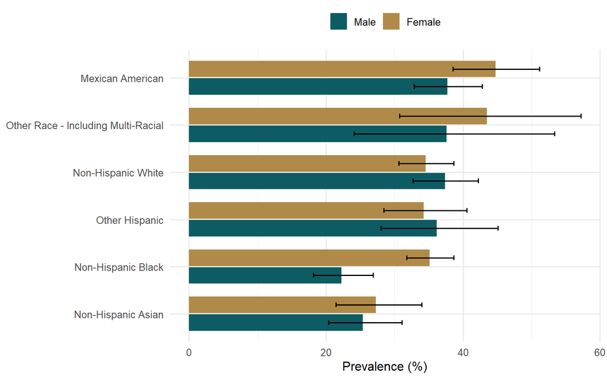

Weighted metabolic syndrome prevalence with 95% CIs.

```r
ggplot(prev_tbl, aes(x = reorder(race_eth, metsyn_pct), y = metsyn_pct, fill = sex)) +
  geom_col(position = position_dodge(0.75), width = 0.7) +
  geom_errorbar(
    aes(ymin = metsyn_pct_low, ymax = metsyn_pct_upp),
    position = position_dodge(0.75), width = 0.2
  ) +
  coord_flip() +
  scale_fill_manual(values = c("Male" = "#0d5c63", "Female" = "#b08a49")) +
  labs(x = NULL, y = "Prevalence (%)", fill = NULL) +
  theme(legend.position = "top")
```